# Predictive Modeling for HR Employee Attrition

Chris Ray

2026-03-20

## 1. Project Description

Employee attrition (turnover) is a major cost to organizations, impacting productivity, morale, and recruitment budgets. This project utilizes machine learning—specifically Logistic Regression—to analyze a dataset of HR records. The goal is to perform business inference: identifying the key drivers behind why employees leave and building a predictive model to flag high-risk employees.

## 2. Business Problem

If the Human Resources department can proactively identify which employees are statistically most likely to quit and understand the reasons why, they can implement targeted retention strategies—such as salary adjustments, remote work flexibility, or role changes—ultimately saving the company significant replacement costs.

## 3. Data Dictionary

*Note: The dataset contains 35 variables; the most critical ones for this analysis are defined below.*

- **Attrition**: Whether the employee left the company (Yes/No) - *Target Variable*
- **Age**: Employee’s age in years
- **DistanceFromHome**: Distance from home to work (in miles)
- **JobSatisfaction**: Rating from 1 (Low) to 4 (High)
- **NumCompaniesWorked**: Number of previous employers
- **MonthlyIncome**: Monthly salary
- **TotalWorkingYears**: Total years of professional experience

## 4. Importing Libraries

```r
# Load necessary libraries for data manipulation and modern visualization
library(ggplot2)
```

## 5. Loading the Dataset

We use a relative file path to ensure this project is fully reproducible on any machine.

```r
# Load the dataset
data <- read.csv("HR-Employee-Attrition.csv", stringsAsFactors = TRUE)

# Display the dimensions of the dataset
dim(data)
```

```
## [1] 1470   35
```

## 6. Data Preprocessing

Before exploring the data, we must remove columns that provide zero predictive value. Columns like EmployeeCount, StandardHours, and Over18 contain the exact same value for every single row (zero variance). EmployeeNumber is simply an identifier.

```r
# Drop zero-variance and ID columns (Notice how this has a # because it is INSIDE the code chunk!)
data <- subset(data, select = -c(EmployeeCount, EmployeeNumber, Over18, StandardHours))

# Check for any missing values
sum(is.na(data))
```

```
## [1] 0
```

**Interpretation:** The dataset contains 0 missing values, meaning we do not need to perform data imputation. The dataset is clean and ready for exploration.

## 7. Exploratory Data Analysis (EDA)

### 7.1 Distribution of the Target Variable (Attrition)

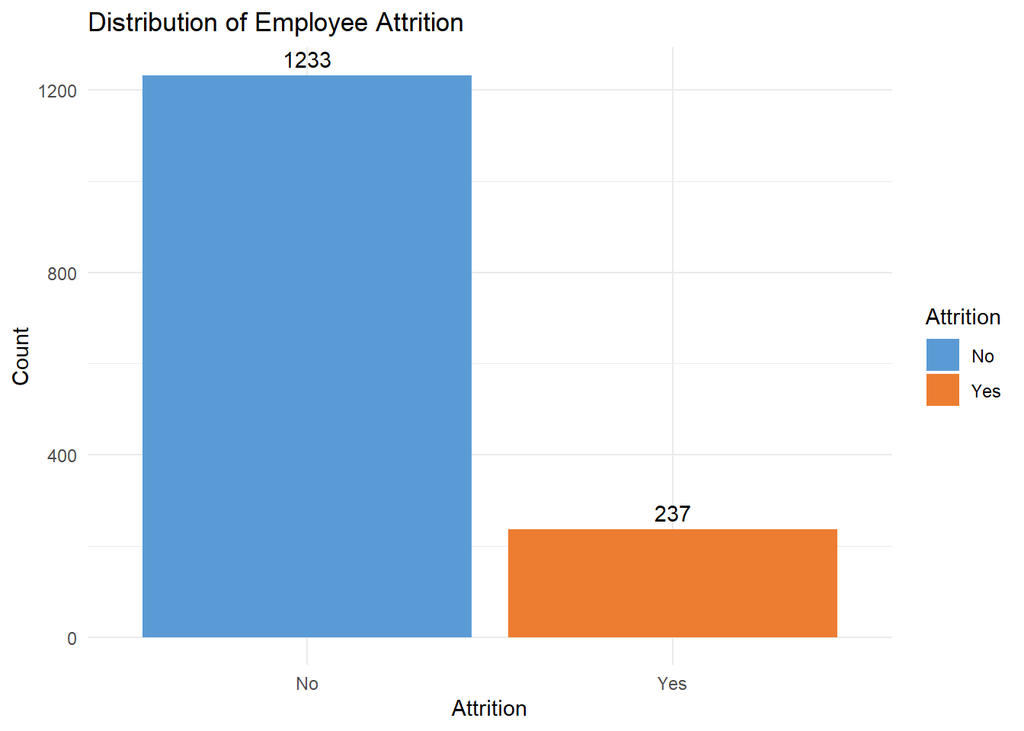

```r
ggplot(data, aes(x = Attrition, fill = Attrition)) +
  geom_bar() +
  theme_minimal() +
  labs(title = "Distribution of Employee Attrition", x = "Attrition", y = "Count") +
  scale_fill_manual(values = c("No" = "#5b9bd5", "Yes" = "#ed7d31")) +
  geom_text(stat='count', aes(label=..count..), vjust=-0.5)
```

**Interpretation:** The dataset is highly imbalanced. The vast majority of employees (1,233) stayed, while a smaller fraction (237) left. This is typical for HR data, but it is a crucial insight: our model must be careful to properly identify the minority class (the “Yes” group) rather than just guessing “No” for everyone.

### 7.2 Number of Companies Worked vs. Attrition

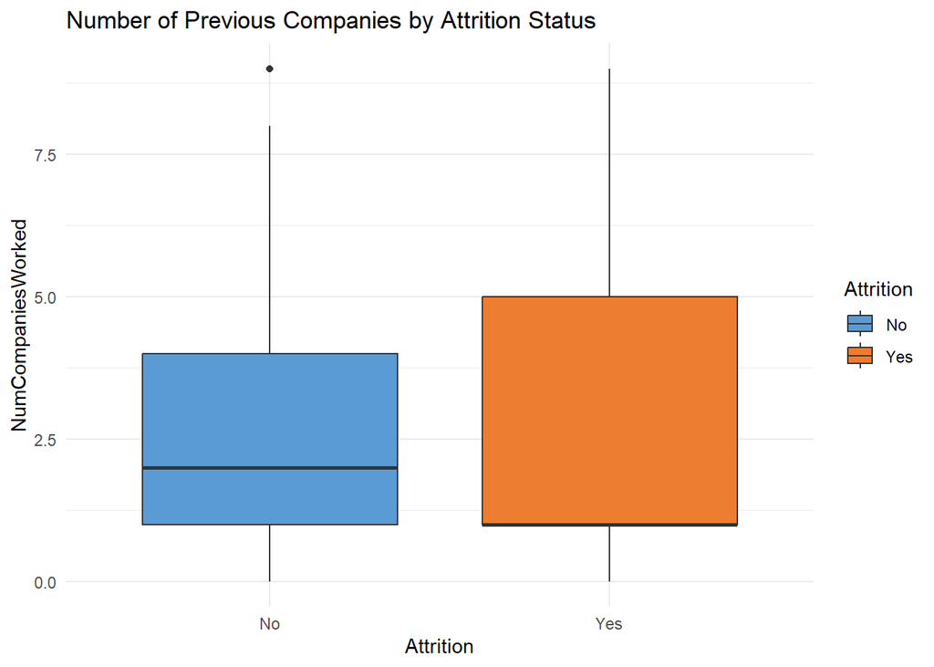

```r
ggplot(data, aes(x = Attrition, y = NumCompaniesWorked, fill = Attrition)) +
  geom_boxplot() +
  theme_minimal() +
  labs(title = "Number of Previous Companies by Attrition Status") +
  scale_fill_manual(values = c("No" = "#5b9bd5", "Yes" = "#ed7d31"))
```

### 7.3 Monthly Income Distribution by Attrition

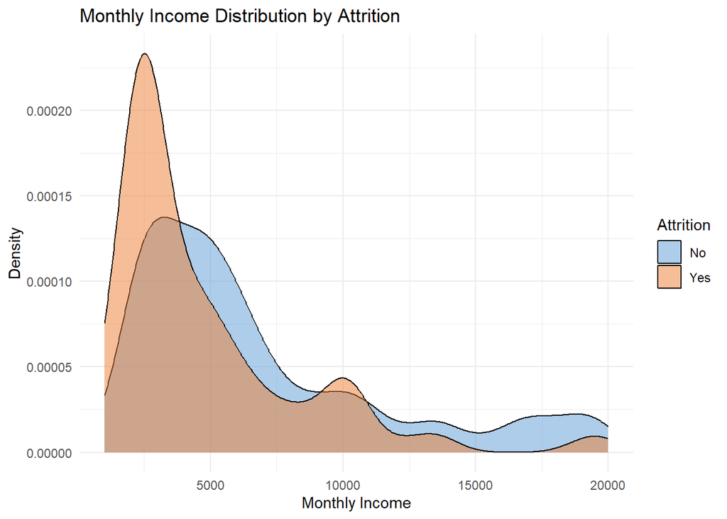

```r
ggplot(data, aes(x = MonthlyIncome, fill = Attrition)) +
  geom_density(alpha = 0.5) +
  theme_minimal() +
  labs(title = "Monthly Income Distribution by Attrition", x = "Monthly Income", y =  "Density") +
  scale_fill_manual(values = c("No" = "#5b9bd5", "Yes" = "#ed7d31"))
```

**Interpretation:** The density plot clearly shows a massive spike in attrition at the lower end of the monthly income scale. Employees making less than $5,000 a month are significantly more likely to leave the company, whereas attrition tapers off heavily for higher earners.

### 7.4 Proportion of Attrition by Job Role

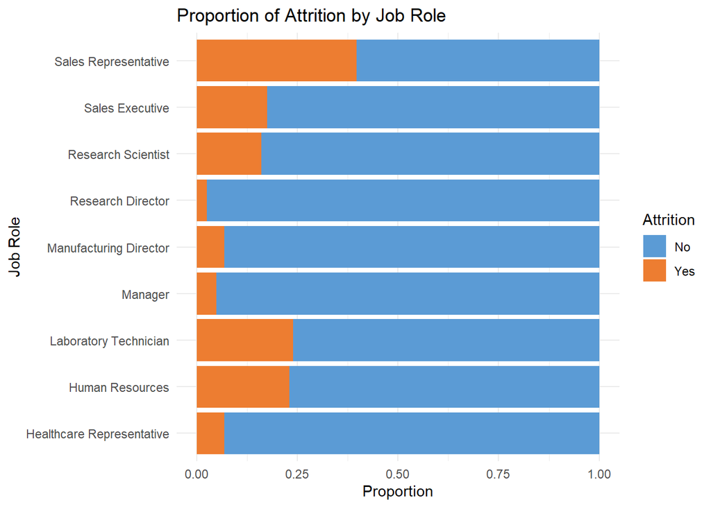

```r
ggplot(data, aes(x = JobRole, fill = Attrition)) +
  geom_bar(position = "fill") +
  theme_minimal() +
  coord_flip() +
  labs(title = "Proportion of Attrition by Job Role", x = "Job Role", y = "Proportion") +
  scale_fill_manual(values = c("No" = "#5b9bd5", "Yes" = "#ed7d31"))
```

**Interpretation:** By looking at the proportions, we can identify specific departments that are “bleeding” talent. Sales Representatives and Laboratory Technicians have the highest proportional turnover rates, indicating that HR should investigate the working conditions or competitive pay within those specific roles.

### 7.5 Age Distribution by Attrition Status

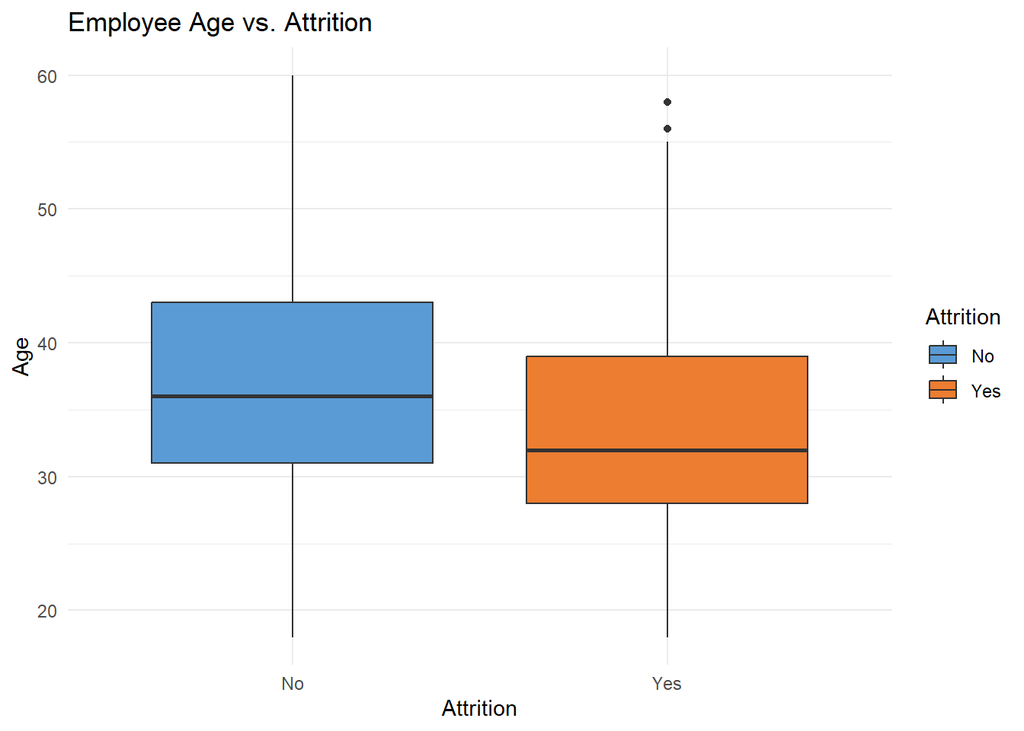

```r
ggplot(data, aes(x = Attrition, y = Age, fill = Attrition)) +
  geom_boxplot() +
  theme_minimal() +
  labs(title = "Employee Age vs. Attrition") +
  scale_fill_manual(values = c("No" = "#5b9bd5", "Yes" = "#ed7d31"))
```

**Interpretation:** The median age of employees who leave is noticeably lower (around 32 years old) compared to those who stay (around 36 years old). This suggests the company is struggling specifically with early-career retention.

## 8. Feature Engineering

```r
# Create new feature: Years spent at previous employment
data$YearsAtLastCompany <- data$TotalWorkingYears - data$YearsAtCompany

# Ensure logical variables are treated as categories
data$Attrition <- as.factor(data$Attrition)
data$BusinessTravel <- as.factor(data$BusinessTravel)
```

### Section 9: Train-Test Split

## 9. Train-Test Split

To ensure our model generalizes well to unseen data, we split our dataset. We will train the model on 70% of the data and test its predictive power on the remaining 30%.

```r
set.seed(123) # Set seed for reproducibility

sample_size <- floor(0.70 * nrow(data))
train_indices <- sample(seq_len(nrow(data)), size = sample_size)

train_data <- data[train_indices, ]
test_data <- data[-train_indices, ]

cat("Training Set:", nrow(train_data), "rows\n")
```

```
## Training Set: 1029 rows
```

```r
cat("Testing Set:", nrow(test_data), "rows\n")
```

```
## Testing Set: 441 rows
```

## 10. Building the Logistic Regression Model

Since our target variable (`Attrition`) is binary (Yes/No), we use Logistic Regression to uncover linear relationships between our features and the log-odds of an employee leaving.

```r
# Build the model on the training data
log_model <- glm(Attrition ~ Age + DistanceFromHome + Gender + JobRole +
                   JobSatisfaction + MaritalStatus + MonthlyIncome,
                 data = train_data, family = binomial)

# Output the model summary
summary(log_model)
```

```
##
## Call:
## glm(formula = Attrition ~ Age + DistanceFromHome + Gender + JobRole +
##     JobSatisfaction + MaritalStatus + MonthlyIncome, family = binomial,
##     data = train_data)
##
## Coefficients:
##                                 Estimate Std. Error z value Pr(>|z|)
## (Intercept)                   -9.935e-01  7.409e-01  -1.341 0.179944
## Age                           -4.058e-02  1.276e-02  -3.180 0.001473 **
## DistanceFromHome               3.060e-02  1.122e-02   2.727 0.006382 **
## GenderMale                    -5.458e-02  1.919e-01  -0.284 0.776046
## JobRoleHuman Resources         1.399e+00  5.968e-01   2.345 0.019045 *
## JobRoleLaboratory Technician   1.086e+00  4.939e-01   2.199 0.027882 *
## JobRoleManager                -4.455e-01  8.827e-01  -0.505 0.613762
## JobRoleManufacturing Director  5.535e-02  5.383e-01   0.103 0.918094
## JobRoleResearch Director      -1.374e+00  1.177e+00  -1.167 0.243157
## JobRoleResearch Scientist      5.915e-01  5.012e-01   1.180 0.237944
## JobRoleSales Executive         6.484e-01  4.510e-01   1.438 0.150506
## JobRoleSales Representative    1.840e+00  5.532e-01   3.326 0.000880 ***
## JobSatisfaction               -3.060e-01  8.266e-02  -3.702 0.000214 ***
## MaritalStatusMarried           3.016e-01  2.826e-01   1.067 0.285806
## MaritalStatusSingle            1.195e+00  2.808e-01   4.255 2.09e-05 ***
## MonthlyIncome                  4.780e-06  5.577e-05   0.086 0.931697
## ---
## Signif. codes:  0 '***' 0.001 '**' 0.01 '*' 0.05 '.' 0.1 ' ' 1
##
## (Dispersion parameter for binomial family taken to be 1)
##
##     Null deviance: 896.03  on 1028  degrees of freedom
## Residual deviance: 764.61  on 1013  degrees of freedom
## AIC: 796.61
##
## Number of Fisher Scoring iterations: 6
```

### 10.1 Converting to Odds Ratios for Business Interpretability

Logistic Regression outputs coefficients in log-odds, which are difficult for non-technical stakeholders to interpret. By exponentiating the coefficients, we get actionable Odds Ratios.

```r
# Calculate Odds Ratios
odds_ratios <- exp(coef(log_model))
print(round(odds_ratios, 3))
```

```
##                   (Intercept)                           Age
##                         0.370                         0.960
##              DistanceFromHome                    GenderMale
##                         1.031                         0.947
##        JobRoleHuman Resources  JobRoleLaboratory Technician
##                         4.053                         2.963
##                JobRoleManager JobRoleManufacturing Director
##                         0.640                         1.057
##      JobRoleResearch Director     JobRoleResearch Scientist
##                         0.253                         1.807
##        JobRoleSales Executive   JobRoleSales Representative
##                         1.912                         6.297
##               JobSatisfaction          MaritalStatusMarried
##                         0.736                         1.352
##           MaritalStatusSingle                 MonthlyIncome
##                         3.302                         1.000
```

- Job Satisfaction (Behavioral): The Odds Ratio is less than 1 (approx 0.73). This means that for every 1-point increase in an employee’s satisfaction rating, their odds of leaving the company drop by about 27%.
- Age (Demographic): The Odds Ratio for Age is ~0.96. For every additional year of age, the odds of attrition decrease by 4%, indicating that older, more established employees offer much higher retention stability.
- Marital Status (Categorical): The model shows that being “Single” has a high positive coefficient compared to being married. Single employees have significantly higher odds of leaving, which may tie into a higher willingness to relocate or take career risks early in life.

## 11. Model Evaluation & Predictions

Let’s test our model against the 30% of data it has never seen before.

```r
# Predict probabilities on the unseen test data
probabilities <- predict(log_model, newdata = test_data, type = "response")

# Convert probabilities to a strict Yes/No prediction (using a 0.5 threshold)
predictions <- ifelse(probabilities > 0.5, "Yes", "No")

# Generate the Confusion Matrix
confusion_matrix <- table(Predicted = predictions, Actual = test_data$Attrition)
print(confusion_matrix)
```

```
##          Actual
## Predicted  No Yes
##       No  360  65
##       Yes   6  10
```

```r
# Calculate Accuracy
accuracy <- sum(diag(confusion_matrix)) / sum(confusion_matrix)
cat("\nModel Accuracy:", round(accuracy * 100, 2), "%\n")
```

```
##
## Model Accuracy: 83.9 %
```

## 12. Conclusion & Key Learnings

Through this analysis, we applied a full end-to-end data science workflow to solve a real-world HR problem using Logistic Regression.

**End of Analysis**